# Praca Domowa 2

Jan Poglod

5/5/2022

# 1. Wprowadzenie

- sqldf
- dplyr
- data.table
- funkcje bazowe R-a

##### Dzięki temu można przeprowadzić badanie, polegające na sprawdzeniu, która biblioteka będzie najskuteczniejszą i najbardziej wydajną do obliczania wyników zadań. Każde z opracowanych przeze mnie zadań jest podzielone kolejno na:

- Wprowadzenie do zadania
- Opis kroków, które posłuży aby wykonać zadanie
- Tabelka ilustrująca wywołanie zadania (obliczony wynik)
- 4 rozwiązania zadań zrobione w bibliotekach **sqldf, dplyr, data.table** oraz za pomocą **funkcji bazowych R-a**
- Pokazanie poprawności każdego z rozwiązań oraz, że dają one identyczne wyniki
- Obliczenie wydajności każdej z funkcji i zademonstrowanie danych w tabelce
- Zilustrowanie za pomocą tabeli kolumnowej wydajności funkcji

#### Na koniec w podsuwowaniu wyciągnięte są wnioski z wydajności każdej z funkcji i komentarze końcowe. Ostateczny efekt to wyłonienie biblioteki, która w przykładowych zadaniach przetwarzania danych okazała się najbardziej wydajna i zilustrowanie wyników na wykresach.

# 2. Omówienie zadań

### Zadanie 1

Krótki opis

| Count | Name |
| --- | --- |
| 9470 | visas |
| 5119 | usa |
| 4601 | uk |
| 4460 | air-travel |
| 3503 | customs-and-immigration |
| 3296 | schengen |
| 2058 | transit |
| 1695 | passports |
| 1665 | indian-citizens |
| 1517 | trains |
| 1456 | canada |
| 1340 | luggage |
| 1258 | tickets |
| 1201 | international-travel |
| 1199 | paperwork |
| 1193 | public-transport |
| 1167 | visa-refusals |
| 1139 | germany |
| 1107 | airports |
| 1056 | europe |
| 1046 | legal |
| 1008 | india |

Aby otrzymać powyższy wynik możemy użyć biblioteki sqldf:

```r
df_sql_1 <- function(Tags){
  df1 <- sqldf("SELECT Count, TagName
               FROM Tags WHERE Count > 1000
               ORDER BY Count DESC")
  return(df1)
}
```

Możemy zastosować drugie rozwiązanie z funkcjami bazowymi R-a:

```r
df_base_1 <- function(Tags){
  x <- Tags[c("TagName", "Count")] # Wybieramy kolumny na których będziemy operować
  x <- as.data.frame(Tags[x$Count > 1000, c("Count", "TagName")]) # Wybieramy tagi, których jest więcej niż 1000
  x <- x[order( x$Count, decreasing = TRUE ), ] # układamy zliczenia tagów malejąco
  rownames(x) <- NULL # usuwamy kolumny indeksów
  return(x)
}
```

Inne rozwiązanie z biblioteką Data.Table:

```r
df_table_1 <- function(Tags){
  t <- as.data.table(Tags) # Tworzymy data.table z ramki danych Tags
  t <- t[ t$Count>1000, ] # Wybieramy tagi, których jest więcej niż 1000
  t[ ,c("ExcerptPostId","WikiPostId","Id" )] <- NULL # usuwamy niepotrzebne dla nas kolumny
  t <- t[order(t$Count, decreasing = TRUE), ] # Układamy zliczenia tagów malejąco
  t <- t[ ,c("Count", "TagName")] # Zamieniamy kolumny miejscami by mieć taki sam wynik
  rownames(t) <- NULL # usuwamy kolumnę indeksów
  t$Count <- as.integer(t$Count) # zmieniamy dane w kolumnie zliczeń tagów na liczbowe wartości
  return(t)
}
```

Rozwiązanie z biblioteką dplyr:

```r
df_dplyr_1 <- function(Tags){
  d <- Tags %>% filter(Count > 1000) # filtrujemy tagi i wybieramy te, których jest więcej niż 1000
  d <- d %>% select(c("TagName","Count")) # Wybieramy kolumny TagName i Count
  d <- d %>% arrange(desc(Count)) # ustawiamy malejąco liczbę zliczeń
  return(d)
}
```

W wyniku działania każdej z powyższych funkcji otrzymamy ten sam wynik, co możemy sprawdzić przy użyciu funkcji:

```r
check <- function(sqldf,base,table,dplyr){
  dplyr::all_equal( sqldf, base, table )
  dplyr::all_equal( sqldf, base, dplyr )
  dplyr::all_equal( table, base, dplyr )
}
#Zwracane są trzy wartości TRUE
```

Pozostało nam jeszcze sprawdzić, która z funkcji jest najszybsza.

| Funkcja | Średnia, jednostka nanosekundy |
| --- | --- |
| sqldf | 12.05 |
| base | 5.35 |
| table | 3.27 |
| dplyr | 4.54 |

Uzyskane wyniki najlepiej zobrazować na tabeli kolumnowej, z której widzimy,  
że najbardziej wydajną funkcją w tym przypadku jest funkcja z biblioteką table.

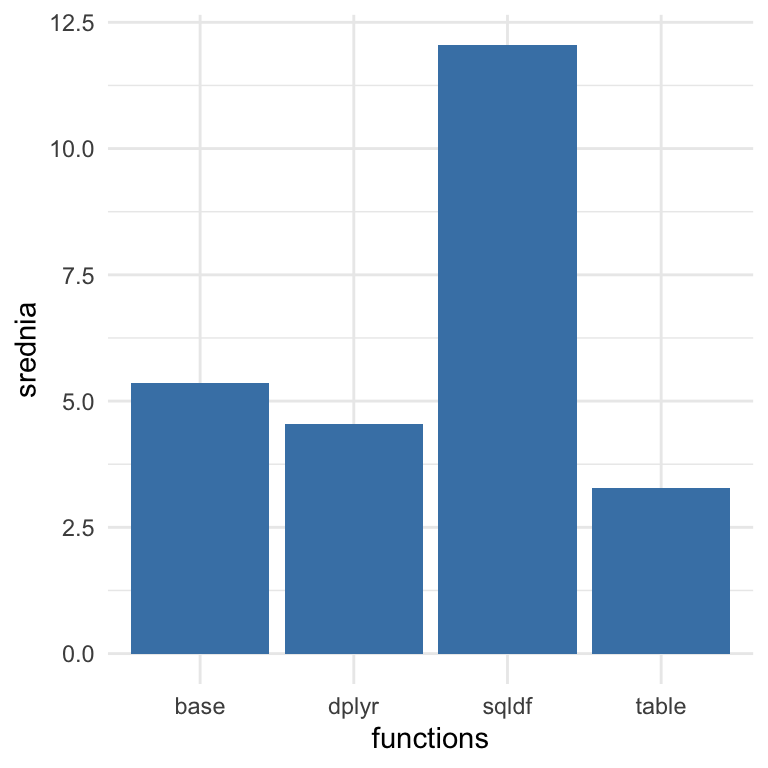

### Zadanie 2

Krótki opis

| Location | Count |
| --- | --- |
| Christchurch New Zealand | 2765 |
| NewYork,NY | 1788 |
| London,United Kingdom | 1708 |
| UK | 1590 |
| Sunshine Coast QLD, Australia | 1550 |
| Australia | 1183 |
| Vancouver, Canada | 967 |
| Netherlands | 935 |
| on the server farm | 924 |
| Pennsylvania | 921 |

Aby otrzymać powyższy wynik możemy użyć biblioteki sqldf:

```r
df_sql_2 <- function(Users,Posts){
  df1 <- sqldf("SELECT Location, COUNT(*) AS Count
  FROM (
  SELECT Posts.OwnerUserId, Users.Id, Users.Location
  FROM Users
  JOIN Posts ON Users.Id = Posts.OwnerUserId
  )
  WHERE Location NOT IN ('')
  GROUP BY Location
  ORDER BY Count DESC
  LIMIT 10")
  View(df1)
  return(df1)
}
```

Rozwiązanie z funkcjami bazowymi:

```r
df_base_2 <- function(Users,Posts){
  u <- Users[c("Id", "Location")] # Wybieramy potrzebne kolumny
  u <- u[u$Location != "", ] # eliminujemy puste lokalizacje
  p <- Posts["OwnerUserId"] # wybieramy potrzebną kolumnę z Posts
  colnames(p) <- "Id" # Zmieniamy nazwę kolumny na "Id"
  merge <- merge(u,p,"Id") # Łączymy ramki wedle Id użytkownika
  agg <- aggregate(merge[1], merge["Location"], length) # Grupujemy dane po lokalizacjach
  x <- agg[order( agg$Id, decreasing = TRUE ), ] # Ustawiamy malejąco po Id
  x <- head(x,10) # Wybieramy tylko 10 pierwszych wierszy
  rownames(x) <- NULL # Usuwamy kolumnę indeksów
  colnames(x) <- c("Location", "Count") # Zmieniamy nazwy kolumn na końcowe
  return(x)
}
```

Rozwiązanie z biblioteką Data.Table:

```r
df_table_2 <- function(Users, Posts){
  u <- as.data.table(Users[c("Id","Location")]) # Wybieramy potrzebne kolumny
  u <- u[ u$Location!="", ] # Eliminujemy puste lokalizacje
  p <- as.data.table(Posts["OwnerUserId"]) # Wybieramy potrzebną kolumnę z Posts
  setnames(p, 'Id') # Zmieniamy nazwę kolumny na Id
  merge <- merge(u,p, by="Id") # Łączymy ramki wedle Id użytkownika
  table <- merge[, .(Count = .N), by = Location] # Tworzymy kolumnę Count, w której zliczamy wystąpienia lokalizacji
  table <- head(table[order(table$Count, decreasing = TRUE), ],10) # Ustawiamy malejąco, wybieramy 10 pierwszych wierszy
  return(table)
}
```

Rozwiązanie z biblioteką dplyr:

```r
df_dplyr_2 <- function(Users, Posts){
  users <- Users %>% select(c("Id","Location")) # Wybieramy potrzebne kolumny z ramki Users
  posts <- Posts %>% select("OwnerUserId") # Wybieramy kolejną potrzebną kolumnę z ramki Posts
  users <- users %>% filter(Location != "") # Eliminujemy lokalizacje bez nazw
  colnames(posts) <- "Id" # Zmieniamy nazwę kolumny na Id
  merge <- users %>% inner_join(posts, by="Id") # Łączymy dane ramki wedle Id użytkownika
  df <- merge %>% group_by(Location) %>% summarise(Count=n()) # Grupujemy i zliczamy lokalizacje pod nazwą Count
  df <- df %>% arrange(desc(Count)) # Ustawiamy malejąco
  df <- head(df,10) # Bierzemy 10 pierwszych wyników
  return(df)
}
```

W wyniku działania każdej z powyższych funkcji otrzymamy ten sam wynik, co możemy sprawdzić przy użyciu funkcji:

```r
check <- function(sqldf,base,table,dplyr){
  dplyr::all_equal( sqldf, base, table )
  dplyr::all_equal( sqldf, base, dplyr )
  dplyr::all_equal( table, base, dplyr )
}
#Zwracane są trzy wartości TRUE
```

Sprawdzmimy, która z funkcji jest najszybsza.

| Funkcja | Średnia, jednostka nanosekundy |
| --- | --- |
| sqldf | 5.42 |
| base | 10.81 |
| table | 2.44 |
| dplyr | 4.93 |

Uzyskane wyniki najlepiej zobrazować na tabeli kolumnowej, z której widzimy,  
że najbardziej wydajną funkcją w tym przypadku jest funkcja z biblioteką table.

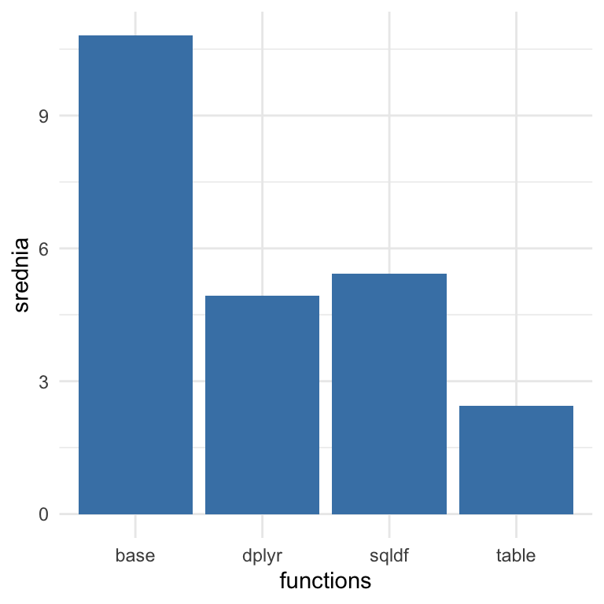

## Zadanie 3

Krótki opis:

*Zadanie to polega na policzeniu lat, w których rejestrowane były bagaże klasy 1. Każdy rok osobno grupujemy i liczymy ile razy był w nim rejestrowany bagaż.*  
Opis kroków:  
Potrzebne informacje wybieramy z dokumentu Badges. Zaczynamy od zmiany daty, która zapisana jest w postaci pełnej tzn. rok-miesiąc-dzień-godzina tak abyśmy mieli tylko rok. Przekształcamy nasze dane tak, aby występowały w nich tylko bagaże klasy 1. Następnoe każdy rok osobno grupujemy i zliczamy go pod nazwą kolumny TotalNumber. Ostateczny wynik ustawiamy tak, aby był od najmniejszej ilości wystąpień do największej.  
Uzyskany wynik wygląda następująco:

| Year | TotalNumber |
| --- | --- |
| 2011 | 16 |
| 2012 | 23 |
| 2013 | 66 |
| 2021 | 153 |
| 2014 | 197 |
| 2020 | 265 |
| 2015 | 328 |
| 2016 | 509 |
| 2017 | 522 |
| 2018 | 697 |
| 2019 | 718 |

Rozwiązanie przy użyciu sql:

```r
df_sql_3 <- function(Badges){
  df1 <- sqldf("SELECT Year, SUM(Number) AS TotalNumber
  FROM (
  SELECT
  Name,
  COUNT(*) AS Number,
  STRFTIME('%Y', Badges.Date) AS Year
  FROM Badges
  WHERE Class = 1
  GROUP BY Name, Year
  )
  GROUP BY Year
  ORDER BY TotalNumber")
  return(df1)
}
```

Rozwiązanie z funkcjami bazowymi:

```r
df_base_3 <- function(Badges){
  # Wybieramy dane tylko z pierwszymi klasami i wybieramy z nich kolumny Date i Name
  badges <- as.data.frame( na.omit( Badges[ Badges$Class == "1", c("Date", "Name") ],  drop=FALSE) )
  date <- format( as.Date( badges[,1] ),"%Y" ) # Zmieniamy datę, aby zlczać tylko rok
  badges$Date <- date # Zmieniamy datę na zapis lat
  colnames(badges) <- c("Year","Name") # Nazwywamy kolumny jako Year i Name
  res <- aggregate(badges, badges[c("Year")], length) # Grupujemy po kolejnych latach i zliczamy ich wystąpienia
  res$Name <- NULL # Usuwamy kolumnę Name, bo nie będzie nam potrzebna
  colnames(res) <- c("Year","TotalNumber") # Nazwywamy kolumny wynikowej ramki jako Year i TotalNumber
  res <- res[order( res$TotalNumber, decreasing = FALSE ), ] # Ustawiamy malejąco od największej ilości zliczeń
  return(res)
}
```

Rozwiązanie z biblioteką Data.Table:

```r
df_table_3 <- function(Badges){
  table <- as.data.table(Badges[c("Date","Name","Class")]) # Wybieramy potrzebne dane do naszej data.table
  table <- table[table$Class=="1"] # Wybieramy dane tylko z klasą pierszą
  table[, Class:=NULL] # Usuwamy kolumn klas, której już nie potrzebujemy
  date <- table$Date # Tworzymy listę, aby zmienić format daty
  year <- as.data.table( year( date ) ) # Korzystam z funkcji data.table year(),aby wybrać tylko rok z całej dat
  setnames( year, "Year" ) # Nazywam kolumnę Year w ramce year
  setnames(table, c( "Year","Name" ) ) # Nazwywam kolumny jako Year i Name w ramce table
  table[ ,1] <- lapply(year, as.character, stringsAsFactors=FALSE) # Zmieniam zapis lat z liczbowego na character
  df <- table[, .(Count = .N), by = Year] # Zliczam liczbę wystąpień każdego roku pod kolumną Count
  df <- (df[order(df$Count, decreasing = FALSE), ]) # Ustawiam malejąco liczbę wystąpień lat
  setnames( df, c("Year","TotalNumber") ) # Nazywam kolumny jako Year i TotalNumber
  return(df)
}
```

Rozwiązanie z biblioteką dplyr:

```r
df_dplyr_3 <- function(Badges){
  badges <- Badges %>% filter(Class == "1") # Wybieramy dane tylko z pierwszą klasę
  badges <- badges %>% select(Name,Date) # Wybieramy potrzbne nam dane z kolumn Name i Date
  date <- badges %>% select(Date) # Tworzymy wartość date do modyfikowania daty
  year <- format(as.Date(date[ ,1]), "%Y") # Zmieniamy date aby został tylko rok
  matrix_year <- year %>% as_tibble() # Tworzymy ramkę danych z naszych zmodyfikowanych dat
  badges$Date <- matrix_year # Zamieniamy zmodyfikowane daty zamiast starych
  df <- badges %>% group_by(Date) %>% # Grupujemy lata po kolejnych
  summarise(TotalNumber=n()) # Zliczamy wystąpienia każdego jako kolumna Count
  colnames(df) <- c("Year","TotalNumber") # Zmieniamy nazwy kolumn na Year i TotalNumber
  df <- df %>% arrange(TotalNumber) # Ustawiamy otrzymaną ramkę malejąco po liczbie wystąpień
  return(df)
}
```

W wyniku działania każdej z powyższych funkcji otrzymamy ten sam wynik, co możemy sprawdzić przy użyciu funkcji:

```r
check <- function(sqldf,base,table,dplyr){
  dplyr::all_equal( sqldf, base, table )
  dplyr::all_equal( sqldf, base, dplyr )
  dplyr::all_equal( table, base, dplyr )
}
#Zwracane są trzy wartości TRUE
```

Sprawdzimy, która z funkcji jest najszybsza.

| Funkcja | Średnia, jednostka nanosekundy |
| --- | --- |
| sqldf | 5.36 |
| base | 6.88 |
| table | 4.95 |
| dplyr | 7.06 |

Uzyskane wyniki najlepiej zobrazować na tabeli kolumnowej, z której widzimy,  
że najbardziej wydajną funkcją w tym przypadku jest także funkcja z biblioteką table.

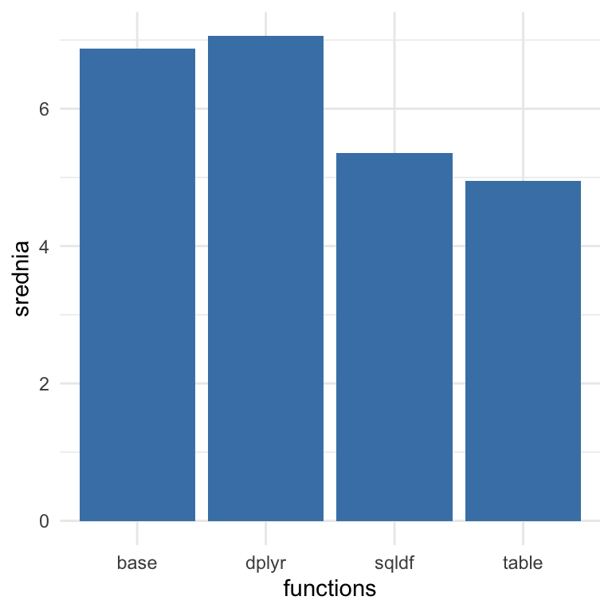

## Zadanie 4

Krótki opis

*Celem tego zadania jest otrzymanie kolumn z Id użytkownika, jego nazwą i lokalizacją oraz zliczenie ParentId pod nazwą kolumny AverageAnswersCount. Zliczamy dane tylko tam gdzie PostTypeId użytkownika jest równe 2.*  
Opis kroków:  
Wybieramy potrzebne dane z plików Users i Posts (kolejno: AccountId, DisplayName, Location, ParentId, OwnerUserId, Id, PostTypeId). Zaczynamy od wybrania tylko tych danych, w których PostTypeId użytkownika jest równe 2. Następnie grupujemy dane wedle ParentId użytkownika i zliczamy liczbę ich wystąpień pod nazwą *AnswersCount*. Łączymy otrzymany wynik z ramką danych Posts, tam, gdzie Id w tej ramce jest równe ParentId w naszym wyniku. Podobnie postępujemyn dla pliku Users, ale porównujemy poprzednie Id użytkowników z OwnerUserId w ramce danych Users i łaczymy dopasowania. Teraz otrzymaliśmy już użytkowników, którzy nas interesują w naszym badaniu, więc wybieramy ich lokalizacje i nazwy. Grupujemy wynik wedle OwnerUserId użytkowników i liczymy średnią arytmetyczną otrzymanych wcześniej, zliczonych *AnswersCount*, wedle tych grup. Ustawiamy otrzymane dane malejąco, od największej otrzymanej średniej arytmetycznej.  
Uzyskany wynik wygląda następująco:

| AccountId | DisplayName | Location | AverageAnswersCount |
| --- | --- | --- | --- |
| 280 | csmba | San Francisco,CA | 11 |
| 40811 | vocaro | San Jose, CA | 11 |
| 204 | Josh | Australia | 10 |
| 44093 | Emma Arbogast | Salem, OR | 10 |
| 11758 | rvarcher | Oklahoma City, OK | 9 |
| 19588 | JD Isaacks | Atlanta, GA | 8 |
| 20473 | Jeremy Boyd | Houston, TX | 8 |
| 42364 | Petrogad |  | 8 |
| 54571 | Christian |  | 8 |
| 79346 | Thomas Matthews | California | 8 |

Zapytanie sql:

```r
df_sql_4 <- function(Users,Posts){
  df <- sqldf("SELECT
  Users.AccountId,
  Users.DisplayName,
  Users.Location,
  AVG(PostAuth.AnswersCount) as AverageAnswersCount
  FROM
  (
  SELECT
  AnsCount.AnswersCount,
  Posts.Id,
  Posts.OwnerUserId
  FROM (
  SELECT Posts.ParentId, COUNT(*) AS AnswersCount
  FROM Posts
  WHERE Posts.PostTypeId = 2
  GROUP BY Posts.ParentId
  ) AS AnsCount
  JOIN Posts ON Posts.Id = AnsCount.ParentId
  ) AS PostAuth
  JOIN Users ON Users.AccountId=PostAuth.OwnerUserId
  GROUP BY OwnerUserId
  ORDER BY AverageAnswersCount DESC, AccountId ASC
  LIMIT 10")
  return(df)
}
```

Rozwiązanie z funkcjami bazowymi:

```r
df_base_4 <- function(Users,Posts){
  p <- Posts[ ( is.na(Posts$PostTypeId)==FALSE & Posts$PostTypeId==2 ), ] # Wybieramy dane gdzie PosTypeId użytkownika jest równe 2
  posts <- p["ParentId"] # Wybieramy kolumnę z ParentId użytkownika
  Id <- Posts[c("Id","OwnerUserId")] # Wybieramy kolumny Id i OwnerUserId i zapisujemy jako ramkę Id
  user <- Users[c("AccountId","Location","DisplayName")] # Wybieramy potrzebne kolumny z pliku Users
  colnames(user) <- c("OwnerUserId","Location","DisplayName") # Nazywamy kolumny
  AnsCount <- aggregate(posts, posts["ParentId"], length) # Grupujemy ramkę danych po ParentId i zliczamy
  colnames(AnsCount) <- c("Id","TotalNumber") # Nazywamy kolumny
  PostAuth <- merge(Id,AnsCount,by="Id") # Łączymy ramki danych Id i pogrupowanych zliczonych ParentId
  merge <- merge(user,PostAuth,by="OwnerUserId") # Łączymy wyniki z linijki wyżej z potrzebnymi kolumnami z pliku Users po OwnerUserId
  df <- merge[is.na(merge$OwnerUserId) == FALSE,] # Usuwamy puste numery OwnerUserId
  df["Id"] <- NULL # Usuwamy kolumnę Id
  average <- df[c("OwnerUserId","TotalNumber")] # Tworzymy zmienną do liczenia średniej arytmetycznej
  average <- average[order( average$OwnerUserId ), ] # Ustawiamy malejąco po OwnerUserId
  mean <- as.data.frame(aggregate(average["TotalNumber"], average["OwnerUserId"], mean)) # Grupujemy dane po OwnerUserId i liczymy średnią z TotalNumber
  df <- merge(df, mean, by="OwnerUserId") # Łączymy nasze wyniki po OwnerUserId
  df <- df[ c( "OwnerUserId","DisplayName","Location","TotalNumber.y" ) ] # wybieramy potrzebne wyniki do ostatecznej ramki
  colnames(df) <- c("AccountId","DisplayName","Location","AverageAnswersCount")
  res <- head( df[ order( df$AverageAnswersCount,decreasing = TRUE ), ], 10 ) # Ustawiamy malejąco po obliczonej średniej arytmetycznej i wybieramy 10 pierwszych wyników
  rownames(res) <- NULL # Usuwamy kolumny indeksów
  return(res)
}
```

Rozwiązanie z biblioteką Data.Table:

```r
df_table_4 <- function(Users, Posts){
  pt <- as.data.table(Posts) # Tworzymy data.table z pliku Posts
  Id <- as.data.table(Posts[c("Id","OwnerUserId")]) # Tworzymy data.table z potrzebnych nam kolumn z pliku Posts
  user <- as.data.table(Users[c("AccountId","Location","DisplayName")]) # Tworzymy data.table z potrzebnych nam kolumn z pliku Users
  posts <- pt[ pt$PostTypeId==2, ] # Wybieramy dane gdzie PosTypeId użytkownika jest równe 2
  setnames(user, c("OwnerUserId","Location","DisplayName") ) # Zmieniamy nazwy kolumn
  AnsCount <- posts[, .(Count = .N), by = ParentId] # Zliczamy wystąpienia ParentId jako Count
  setnames(AnsCount, c("Id","TotalNumber")) # Zmieniamy nazwy
  PostAuth <- merge( Id, AnsCount, by="Id" ) # Łączymy uzyskane ramki danych po Id użytkownika
  merge <- merge( user, PostAuth, by="OwnerUserId" ) # Łączymy uzyskane ramki danych po OwnerUserId użytkownika
  df <- merge[ is.na( merge$OwnerUserId ) == FALSE, ] # Usuwamy dane gdzie nie istnieją OwnerUserId
  df[ , Id:=NULL ] # Usuwamy kolumnę Id
  df[ ,1] <- lapply( df[ ,1], as.character, stringsAsFactors=FALSE ) # Modyfikujemy zliczenia, aby zapisać je jako character (napis)
  average <- df # Tworzymy zmienną do liczenia średniej arytmetycznej
  average <- average[, Location:=NULL] # Usuwamy niepotrzebną kolumnę lokalizacje
  average <- average[, DisplayName:=NULL] # Usuwamy niepotrzebną kolumnę nazw
  average <- average[order( average$OwnerUserId ), ] # Ustawiamy OwnerUserId od największych do najmniejszych
  mean <- average[ , (mean=mean(TotalNumber) ), by = OwnerUserId] # Grupujemy dane po OwnerUserId Zliczamy średnią arytmetyczną z ParentId
  table <- merge[is.na(merge$OwnerUserId) == FALSE, ] # Usuwamy dane, które nie isntieją z OwnerUserId
  table[ ,1] <- lapply(table[ ,1], as.character, stringsAsFactors=FALSE) # Modyfikujemy zliczenia, aby zapisać je jako character (napis)
  res <- merge(table, mean, by="OwnerUserId") # Łączymy dane po OwnerUserId
  res <- res[order(-res$V1),] # Ustawiamy zliczoną średnią arytmetyczną malejąco
  res[, Id:=NULL] # Usuwamy kolumnę Id
  res[, TotalNumber:=NULL] # Usuwamy kolumnę TotalNumber
  setnames(res, c("AccountId","DisplayName","Location","AverageAnswersCount")) # Zmieniamy nazwy kolumn
  res <- head( res,10 ) # Wybieramy tylko 10 pierwszych wierszy
  res[ ,c("Location", "DisplayName") := .(DisplayName, Location)] # Zamieniamy miejscami kolumny z lokalizacjami i nazwami
  res$AccountId <- as.integer(res$AccountId) # Zmieniamy kolumnę AccountId na liczbowe wartości
  rownames(res) <- NULL # Usuwamy kolumnę z indeksami
  return(res)
}
```

Rozwiązanie z biblioteką dplyr:

```r
df_dplyr_4 <- function(Users, Posts){
  p <- Posts %>% filter(PostTypeId==2) # Wybieramy dane gdzie PosTypeId użytkownika jest równe 2
  posts <- p %>% select(ParentId) # Wybierammy kolumnę ParentId
  Id <- Posts %>% select(Id,OwnerUserId) # Wybieramy kolumny Id i OwnerUserId i nazywamy jako Id
  user <- Users %>% select(AccountId,Location,DisplayName) # Wybieramy potrzebne kolumny z pliku Users
  colnames(user) <- c("OwnerUserId","Location","DisplayName") # Zmieniamy nazwy
  AnsCount <- posts %>% group_by(ParentId) %>% summarise(TotalNumber=n()) # Grupujemy wynik po ParentId i zliczamy liczbę wystąpień jako TotalNumber
  colnames(AnsCount) <- c("Id","TotalNumber") # Zmieniamy nazwy kolumn
  PostAuth <- Id %>% inner_join(AnsCount, by="Id") # Łączymy wyniki po Id użytkownika
  merge <- user %>% inner_join(PostAuth, by="OwnerUserId") # Łączymy wyniki z linijki wyżej i users po OwnerUserId
  merge <- merge[is.na(merge$OwnerUserId) == FALSE,] # Usuwamy nieistniejące OwnerUserId
  average <- merge %>% select(OwnerUserId,TotalNumber) %>% as_tibble() # Tworzymy zmienną do wyznaczania średniej
  average <- average %>% arrange(OwnerUserId) # Sortujemy dane po OwnerUserId
  mean <- average %>% group_by(OwnerUserId) %>% summarise(n = n(),TotalNumber = mean(TotalNumber, na.rm = TRUE)) # Grupujemy OwnerUserId, zliczamy wystąpeinia wyniku jako TotalNumber i liczymy średnią arytmetyczną
  df <- merge %>% inner_join(mean, by="OwnerUserId") # Łączymy otrzymane dane po OwnerUserId
  df <- df %>% select(OwnerUserId,DisplayName,Location,TotalNumber.y) # Wybieramy potrzebne kolumny
  colnames(df) <- c("AccountId","DisplayName","Location","AverageAnswersCount") #Zmieniamy nazwy
  df <- df %>% arrange(desc(AverageAnswersCount),AccountId) #Sortujemy malejąco po naszej średniej
  df <- head( df, 10 ) # Wyświetlamy 10 pierwszych wierszy
  rownames(df) <- NULL
  return(df)
}
```

Sprawdzimy, która z funkcji jest najszybsza.

| Funkcja | Średnia, jednostka nanosekundy |
| --- | --- |
| sqldf | 6.18 |
| base | 6.20 |
| table | 4.12 |
| dplyr | 6.60 |

Uzyskane wyniki najlepiej zobrazować na tabeli kolumnowej, z której widzimy,  
że najbardziej wydajną funkcją w tym przypadku jest funkcja z biblioteką table.

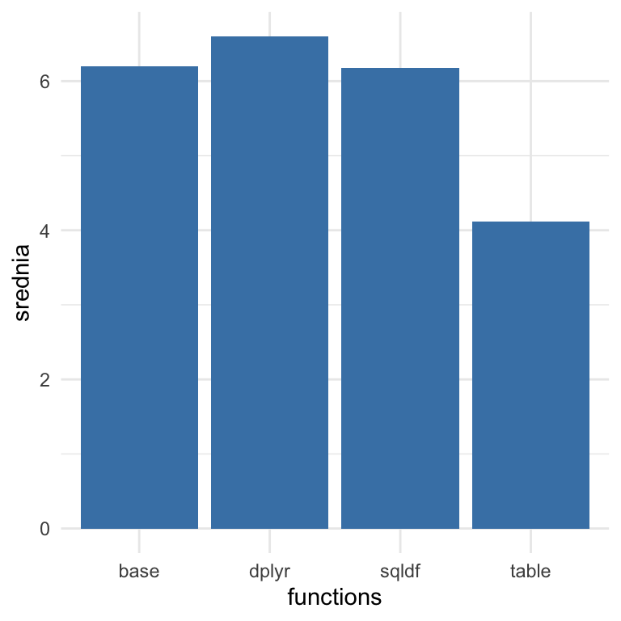

## *Zadanie 5*

Wynik otrzymanej ramki danych wygląda następująco:

| Title | Id | Date | Votes |
| --- | --- | --- | --- |
| What’s the longest distance that can be traveled by only using free transportation? | 151994 | 09.01.2020 | 140 |
| Considerations for very fragile and expensive (> $100,000) items in carry-on luggage | 157138 | 10.05.2020 | 108 |
| What are these chair-like things in hotels? | 153605 | 10.02.2020 | 94 |
| What to do if I overstayed my e-visa for Saint Petersburg/Leningrad Oblast | 152418 | 18.01.2020 | 84 |
| What are the hidden fees of a cruise? | 152178 | 13.01.2020 | 80 |
| What happens when a town is under quarantine and my visa expires | 152677 | 23.01.2020 | 76 |
| I’ve been warned to leave the US within 10 days as I will “overstay” my visa, but I have legally left the country by plane months ago. What can I do? | 156945 | 28.04.2020 | 72 |
| When an individual enters the United States, can they have an attorney present when going through the U.S. Customs and Border Protection? | 159298 | 06.09.2020 | 68 |
| Is Seiryu Miharashi Station the only train station where passengers cannot enter or exit the platform? | 162386 | 04.02.2021 | 64 |
| Positive drug test in Singapore: How long do I need to avoid the country? | 163264 | 08.04.2021 | 64 |

Zapytanie sql:

```r
df_sql_5 <- function(Votes,Posts){
  df <- sqldf("SELECT Posts.Title, Posts.Id,
  STRFTIME('%Y-%m-%d', Posts.CreationDate) AS Date,
  VotesByAge.Votes
  FROM Posts
  JOIN (
  SELECT
  PostId,
  MAX(CASE WHEN VoteDate = 'new' THEN Total ELSE 0 END) NewVotes,
  MAX(CASE WHEN VoteDate = 'old' THEN Total ELSE 0 END) OldVotes,
  SUM(Total) AS Votes
  FROM (
  SELECT
  PostId,
  CASE STRFTIME('%Y', CreationDate)
  WHEN '2021' THEN 'new'
  WHEN '2020' THEN 'new'
  ELSE 'old'
  END VoteDate,
  COUNT(*) AS Total
  FROM Votes
  WHERE VoteTypeId IN (1, 2, 5)
  GROUP BY PostId, VoteDate
  ) AS VotesDates
  GROUP BY VotesDates.PostId
  HAVING NewVotes > OldVotes
  ) AS VotesByAge ON Posts.Id = VotesByAge.PostId
  WHERE Title NOT IN ('')
  ORDER BY Votes DESC
  LIMIT 10")
  return(df)
}
```

Otrzymaliśmy następujące informacje o wydajności podanej funkcji:

| Funkcja | Średnia, jednostka nanosekundy |
| --- | --- |
| sqldf | 9.93 |

# 3. Podsumowanie

#### Otrzymując wyniki z wszystkich powyższych zadań możemy przeanalizować która z używanych bibliotek programistycznych jest najbardziej wydajna.

Otrzymane, interesujące do naszego badania informacje, możemy pozyskać z wykresów, które były skutkiem zliczenia średniego czasu wykonywania naszych funkcji. Dane prezentują się następująco:

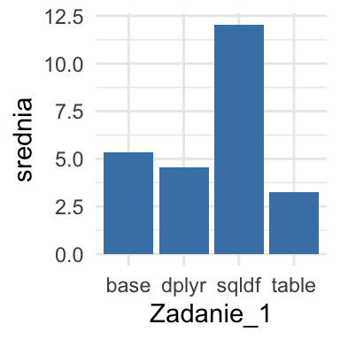

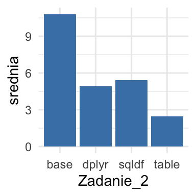

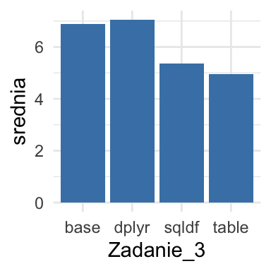

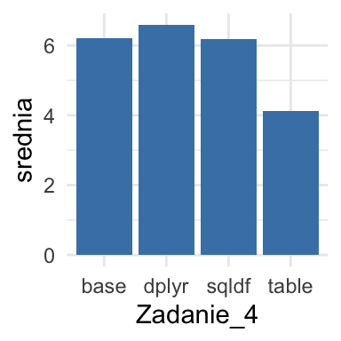

#### Policzmy średnią aytmetyczną, grupując po bibliotekach, ze wszystkich powyższych wykresów tak, aby otrzymać średni wynik, dla naszych przykładowych zadań. Wykres otrzymany w taki sposób prezentuję się następująco:

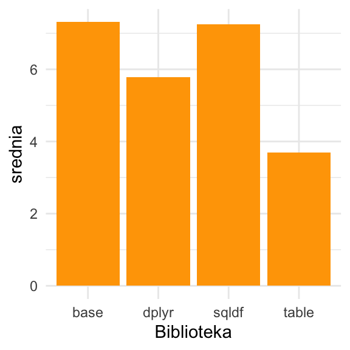

**2. Analiza Wykresów z wynikami z każdego zadania osobno**

#### Omówienie biblioteki dplyr

Biblioteka dplyr słabo liczy wyniki w zadaniach, które są długie i wymagają dużo kodu, ale porównywalnie z innymi i nie ma wiele opóźnienia. Najszybciej liczy zaś zadania krótkie i prezentuje się wtedy najlepiej po data.table.

#### Omówienie funkcji bazowych R-a

Funkcja bazowa R-a (base) najgorzej pośród innych badancych bibliotek poradziła sobie w zadaniu 2, w którym nie było dużo kodu do napisania i sporych wyników do liczenia. Biblioteki dplyr i data.table wychodzą w takich zadaniach znacznie lepiej, dlatego wykorzystując je mamy wydajniejszy kod. W tym zestawieniu base porównywalnie do biblioteki dplyr obliczyło zadania z większą ilością kodu i nie wychodzi w takich zadaniach najgorzej.

#### Omówienie biblioteki data.table

Na każdym z analizowanych wykresów funkcje z biblioteką data.table miały najszybszy czas obliczania wyników, zatem oczywistym wnioskiem z przeprowadzonego badania jest, że jest to najbardziej wydajna biblioteka spośród pozostałych oraz jeżeli chcemy, aby nas program był szybki najlepiej jest z niej korzystać.

### **Wykres kołowy prezentujący średni czas działania funkcji z badanych bibliotek:**

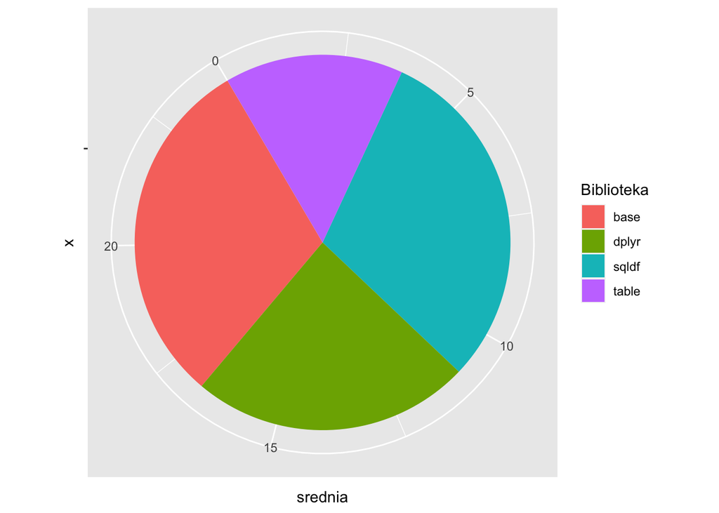